# 淺談R語言與機器學習

# 探索資料框的基本函數

- 善用`?`或`help()`來幫助你瞭解函數

```r
nrow(cars)
```

```
## [1] 50
```

```r
ncol(cars)
```

```
## [1] 2
```

```r
dim(cars)
```

```
## [1] 50  2
```

```r
class(cars)
```

```
## [1] "data.frame"
```

```r
str(cars)
```

```
## 'data.frame':    50 obs. of  2 variables:
##  $ speed: num  4 4 7 7 8 9 10 10 10 11 ...
##  $ dist : num  2 10 4 22 16 10 18 26 34 17 ...
```

```r
head(cars)
```

```
##   speed dist
## 1     4    2
## 2     4   10
## 3     7    4
## 4     7   22
## 5     8   16
## 6     9   10
```

```r
tail(cars, n = 10)
```

```
##    speed dist
## 41    20   52
## 42    20   56
## 43    20   64
## 44    22   66
## 45    23   54
## 46    24   70
## 47    24   92
## 48    24   93
## 49    24  120
## 50    25   85
```

```r
summary(cars)
```

```
##      speed           dist
##  Min.   : 4.0   Min.   :  2.00
##  1st Qu.:12.0   1st Qu.: 26.00
##  Median :15.0   Median : 36.00
##  Mean   :15.4   Mean   : 42.98
##  3rd Qu.:19.0   3rd Qu.: 56.00
##  Max.   :25.0   Max.   :120.00
```

# 什麼是機器學習?

- 什麼是樹
- 購物籃推薦(Target)
- 電影推薦(Netflix)
- 無人車
- 判別垃圾郵件(Gmail: 主要/社交網路/促銷網路)
- 在臉書照片上標註你自己與朋友
- 預測2016年7月台幣兌日幣的匯率

# 什麼不是機器學習?

- 資料中出現最多的顏色是什麼?
- 2016年波士頓馬拉松男子組冠軍的成績?
- 哪一門課是系統訓練班人數最多的?
- 計算2015年台灣的薪資中位數

# 機器學習的基本種類

- 監督式學習
  - 分類(Classification)
  - 迴歸分析(Regression)
- 非監督式學習
  - 分群(Clustering)

# 分類

- 目標:預測新資料的類別
- 利用歷史資料建立出分類器
- 利用分類器預測新資料所屬類別

# 分類(決策樹範例)

- 到[Kaggle](https://www.kaggle.com/c/titanic/data)將資料集 `train.csv` 下載到本機
- 了解欄位意思
- 對資料框使用函數暸解結構

```r
# 載入需要使用的套件
packages <- c("rpart", "rattle", "rpart.plot", "RColorBrewer", "magrittr")
# 如果不想一一裝的話
#for (i in packages){
#  install.packages(i)
#}
sapply(packages, FUN = library, character.only = TRUE)
```

```r
# 讀取資料
titanic <- read.csv("/Users/tkuo/ntu_train/NTUTrainRL3/data/train.csv", header = TRUE)
titanic <- titanic[, -c(4, 9, 11)] %>% na.omit
str(titanic)
```

```
## 'data.frame':    714 obs. of  9 variables:
##  $ PassengerId: int  1 2 3 4 5 7 8 9 10 11 ...
##  $ Survived   : int  0 1 1 1 0 0 0 1 1 1 ...
##  $ Pclass     : int  3 1 3 1 3 1 3 3 2 3 ...
##  $ Sex        : Factor w/ 2 levels "female","male": 2 1 1 1 2 2 2 1 1 1 ...
##  $ Age        : num  22 38 26 35 35 54 2 27 14 4 ...
##  $ SibSp      : int  1 1 0 1 0 0 3 0 1 1 ...
##  $ Parch      : int  0 0 0 0 0 0 1 2 0 1 ...
##  $ Fare       : num  7.25 71.28 7.92 53.1 8.05 ...
##  $ Embarked   : Factor w/ 4 levels "","C","Q","S": 4 2 4 4 4 4 4 4 2 4 ...
##  - attr(*, "na.action")=Class 'omit'  Named int [1:177] 6 18 20 27 29 30 32 33 37 43 ...
##   .. ..- attr(*, "names")= chr [1:177] "6" "18" "20" "27" ...
```

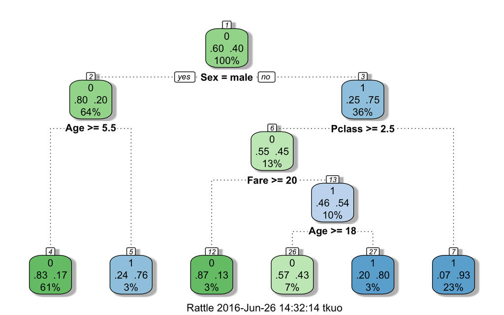

```r
# 隨機排列資料集
n <- nrow(titanic)
set.seed(123)
shuffledTitanic <- titanic[sample(n), ]

# 將資料集分為訓練與測試
trainIndices <- 1:round(0.7 * n)
train <- shuffledTitanic[trainIndices, ]
testIndices <- (round(0.7 * n) + 1):n
test <- shuffledTitanic[testIndices, ]

# 建立一個決策樹模型
tree <- rpart(formula = Survived ~ ., data = train, method = "class")
prediction <- predict(tree, newdata = test, type="class")
fancyRpartPlot(tree)
```

```r
confusionMatrix <- table(x = test$Survived, y = prediction, dnn=c("Actual", "Prediction"))
confusionMatrix
```

```
##       Prediction
## Actual   0   1
##      0 117   7
##      1  38  52
```

- 這裡的 train, test 跟 Kaggle 提供的容易混淆, 一定要搞清楚

# 迴歸分析

- 目標:預測新資料的數值
- 利用歷史資料建立出迴歸模型
- 利用迴歸模型預測新資料的數值

# 迴歸分析(單變數迴歸範例)

- 對資料框使用函數暸解結構

```r
# 氣溫與冰紅茶銷量
temperature <- c(29, 28, 34, 31, 25, 29, 32, 31, 24, 33, 25, 31, 26, 30)
icedTeaSales <- c(77, 62, 93, 84, 59, 64, 80, 75, 58, 91, 51, 73, 65, 84)
toBePredicted <- data.frame(temperature = 30)

# 建立一個線性迴歸模型
icedTeaData <- data.frame(temperature = temperature, icedTeaSales = icedTeaSales)
lmIcedTea <- lm(formula = icedTeaSales ~ temperature, data = icedTeaData)
predicted <- predict(lmIcedTea, newdata = toBePredicted)

# 模型摘要
summary(lmIcedTea)
```

```
##
## Call:
## lm(formula = icedTeaSales ~ temperature, data = icedTeaData)
##
## Residuals:
##    Min     1Q Median     3Q    Max
## -8.037 -5.693  2.094  4.409  8.225
##
## Coefficients:
##             Estimate Std. Error t value Pr(>|t|)
## (Intercept) -36.3612    14.6873  -2.476   0.0292 *
## temperature   3.7379     0.5012   7.457 7.66e-06 ***
## ---
## Signif. codes:  0 '***' 0.001 '**' 0.01 '*' 0.05 '.' 0.1 ' ' 1
##
## Residual standard error: 5.709 on 12 degrees of freedom
## Multiple R-squared:  0.8225, Adjusted R-squared:  0.8077
## F-statistic: 55.61 on 1 and 12 DF,  p-value: 7.661e-06
```

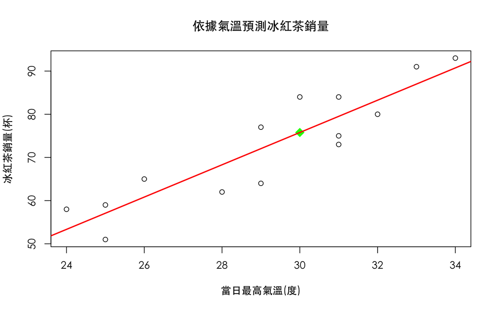

```r
# 作圖
plot(icedTeaSales ~ temperature, main = "依據氣溫預測冰紅茶銷量", xlab = "當日最高氣溫(度)", ylab = "冰紅茶銷量(杯)", family = "STHeiti")
points(x = toBePredicted$temperature, y = predicted, col="green", cex = 2, pch = 18)
abline(reg = lmIcedTea$coefficients, col = "red", lwd = 2)
```

# 分群

- 目標:將資料分成群組
- 掌握組內差異小、組間差異大的原則

# 分群(k-means 範例)

- 對資料框使用函數暸解結構

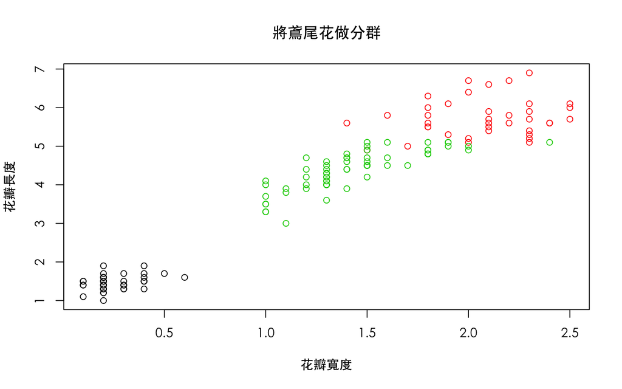

```r
# 建立一個分群模型
irisCluster <- iris[-5]
kmeansIris <- kmeans(irisCluster, centers = 3, nstart = 10)

# 作圖
plot(formula = Petal.Length ~ Petal.Width, data = irisCluster, col = kmeansIris$cluster, main = "將鳶尾花做分群", xlab = "花瓣寬度", ylab = "花瓣長度", family = "STHeiti")
```

# Do It Yourself

- 註冊一個[Kaggle](https://www.kaggle.com/)帳號
- 將[UCI Repository](https://archive.ics.uci.edu/ml/index.html)加入**我的最愛**
- 註冊一個[Github](https://github.com/)帳號
- 把 R 跟 R Studio 在自己的電腦上安裝好

# 深入鑽研

- [Andrew Ng, Machine Learning](https://www.coursera.org/learn/machine-learning)
- [Johns Hopkins University, Practical Machine Learning](https://www.coursera.org/learn/practical-machine-learning)
- [林軒田，機器學習基石](https://www.youtube.com/user/hsuantien/playlists)
- [林軒田，機器學習技法](https://www.youtube.com/playlist?list=PLXVfgk9fNX2IQOYPmqjqWsNUFl2kpk1U2)